# Index Swapping

First lets load the JSON object from the python script and link some names to make life easier.

```r
base=fromJSON('/home/christian/gdrive/School/bi622/index_hopping/counts/count_0')
meta=base$metadata
codes=base$code_set
qual=base$qual_info
tags=base$tag_counts
rd_avg=t(qual$read_avg_dist)
```

Print the metadata for posterity.

```r
print(meta)
```

```
## $index2_file
## [1] "1294_S1_L008_R3_001.fastq.gz"
##
## $cutoff
## [1] 0
##
## $gzip
## [1] TRUE
##
## $index_col
## [1] 5
##
## $out_dir
## [1] "/home/cerikson/jobs/622_index/count_10"
##
## $read2_file
## [1] "1294_S1_L008_R4_001.fastq.gz"
##
## $rev_comp
## [1] TRUE
##
## $known_file
## [1] "indexes.txt"
##
## $index1_file
## [1] "1294_S1_L008_R2_001.fastq.gz"
##
## $read1_file
## [1] "1294_S1_L008_R1_001.fastq.gz"
```

# Part 1

## A.

Turn in the 8 histograms.

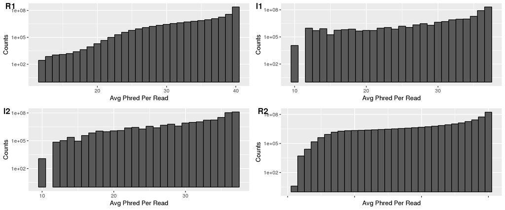

```r
ggarrange(rr1, ri1, ri2, rr2 + rremove("x.text"),
          labels = c("R1", "I1", "I2", "R2"),
          ncol = 2, nrow = 2)
```

[figure not shown]

```r
ggarrange(pr1, pi1, pi2, pr2 + rremove("x.text"),
          labels = c("R1", "I1", "I2", "R2"),
          ncol = 2, nrow = 2)
```

The average quality of reads was R1: 38.7593817188225, I1: 35.5063123251769, I2: 34.5865032564927, R2: 36.9187733566878

And the total number of reads was R1: 363246735, I1: 363246735, I2: 363246735, R2: 363246735

## B.

What is a good quality score cutoff for index reads and pairs to utilize for sample identification and downstream analysis, respectively?

**A Cutoff of 20 would seem to be good.**

## C.

How many indexes have Undetermined (N) base calls? (Utilize your command line tool knowledge. Summit the command you used. CHALLENGE: use a one line command)

```bash
ssh hpc "zcat ~/jobs/622_index/1294*.gz | sed -n '2~4p' | awk 'BEGIN {Ns=0} /N/{Ns+=1} END {print Ns}'"
```

`13499075`

## D.

What do the averaged Quality Scores across the reads tell you? Interpret your data specifically.

**That the vast majority of reads fall above a score on 15. And follow a sigmoid curve.**

# Part 2.

Write a program to document index swapping and number of reads retained per sample.

Load the JSON for the good cutoff and link some names to make life easier.

```r
base=fromJSON('/home/christian/gdrive/School/bi622/index_hopping/counts/count_20')
meta=base$metadata
codes=base$code_set
qual=base$qual_info
tags=base$tag_counts
rd_avg=t(qual$read_avg_dist)
```

Print the metadata for posterity.

```r
print(meta)
```

```
## $index2_file
## [1] "1294_S1_L008_R3_001.fastq.gz"
##
## $cutoff
## [1] 20
##
## $gzip
## [1] TRUE
##
## $index_col
## [1] 5
##
## $out_dir
## [1] "/home/cerikson/jobs/622_index/count_5"
##
## $read2_file
## [1] "1294_S1_L008_R4_001.fastq.gz"
##
## $rev_comp
## [1] TRUE
##
## $known_file
## [1] "indexes.txt"
##
## $index1_file
## [1] "1294_S1_L008_R2_001.fastq.gz"
##
## $read1_file
## [1] "1294_S1_L008_R1_001.fastq.gz"
```

## A.

How many reads are retained for each expected index pair? What is the percentage?

**Reads for each of the correct barcode pairs: “I1_I2 Count proportion”**

GTAGCGTA_GTAGCGTA 6816735 0.0242996679827651, AGGATAGC_AGGATAGC 7291889 0.0259934531219384, CGATCGAT_CGATCGAT 4852641 0.0172982469084618, TCGACAAG_TCGACAAG 3176139 0.0113220072611172, GATCAAGG_GATCAAGG 5559436 0.0198177645121061, ACGATCAG_ACGATCAG 6893551 0.0245734945721461, TCTTCGAC_TCTTCGAC 35312354 0.125878221449105, CGGTAATC_CGGTAATC 3620467 0.0129059067196477, AGAGTCCA_AGAGTCCA 9327234 0.0332488631870768, TCGGATTC_TCGGATTC 3659488 0.0130450051801798, CTAGCTCA_CTAGCTCA 15091465 0.0537966620197968, ATCGTGGT_ATCGTGGT 5737265 0.0204516729239348, ATCATGCG_ATCATGCG 8419208 0.0300120158811865, TAGCCATG_TAGCCATG 8852290 0.0315558266365278, CTCTGGAT_CTCTGGAT 29237911 0.104224607500458, TGTTCCGT_TGTTCCGT 13578756 0.0484042965465108, TACCGGAT_TACCGGAT 60731667 0.216490643121649, CACTTCAC_CACTTCAC 3277838 0.0116845344730712, TCGAGAGT_TCGAGAGT 9307236 0.0331775761617899, AACAGCGA_AACAGCGA 7505874 0.0267562471066381, TATGGCAC_TATGGCAC 9219872 0.0328661490352188, GCTACTCT_GCTACTCT 5634659 0.0200859125220651, GTCCTAAG_GTCCTAAG 7370239 0.0262727479729851, GATCTTGC_GATCTTGC 3129988 0.0111574924344336

**Reads for each of the correct barcode pairs: “I1_I2 Count proportion”**

GTAGCGTA_GTAGCGTA 6816735 0.0242996679827651, AGGATAGC_AGGATAGC 7291889 0.0259934531219384, CGATCGAT_CGATCGAT 4852641 0.0172982469084618, TCGACAAG_TCGACAAG 3176139 0.0113220072611172, GATCAAGG_GATCAAGG 5559436 0.0198177645121061, ACGATCAG_ACGATCAG 6893551 0.0245734945721461, TCTTCGAC_TCTTCGAC 35312354 0.125878221449105, CGGTAATC_CGGTAATC 3620467 0.0129059067196477, AGAGTCCA_AGAGTCCA 9327234 0.0332488631870768, TCGGATTC_TCGGATTC 3659488 0.0130450051801798, CTAGCTCA_CTAGCTCA 15091465 0.0537966620197968, ATCGTGGT_ATCGTGGT 5737265 0.0204516729239348, ATCATGCG_ATCATGCG 8419208 0.0300120158811865, TAGCCATG_TAGCCATG 8852290 0.0315558266365278, CTCTGGAT_CTCTGGAT 29237911 0.104224607500458, TGTTCCGT_TGTTCCGT 13578756 0.0484042965465108, TACCGGAT_TACCGGAT 60731667 0.216490643121649, CACTTCAC_CACTTCAC 3277838 0.0116845344730712, TCGAGAGT_TCGAGAGT 9307236 0.0331775761617899, AACAGCGA_AACAGCGA 7505874 0.0267562471066381, TATGGCAC_TATGGCAC 9219872 0.0328661490352188, GCTACTCT_GCTACTCT 5634659 0.0200859125220651, GTCCTAAG_GTCCTAAG 7370239 0.0262727479729851, GATCTTGC_GATCTTGC 3129988 0.0111574924344336

## B.

How many reads are indicative of index swapping?

**The sum of swapped reads is 432046 or the proportion is 0.0015401 of all reads**

## C.

Create a distribution of swapped indexes. What does this heatmap tell you/what is your interpretation of this data?

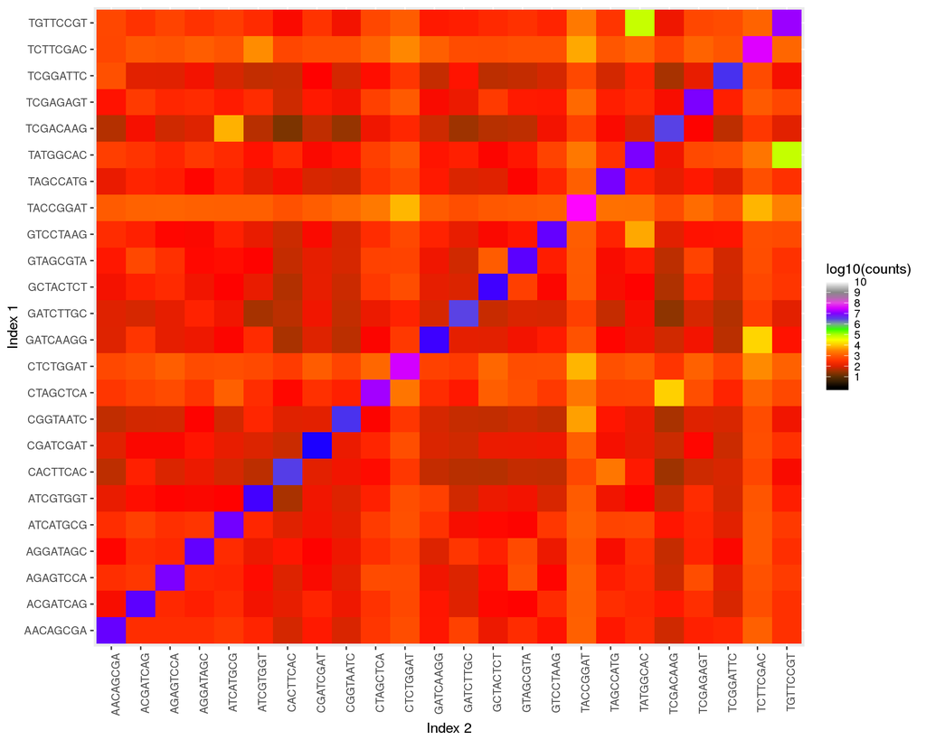

```r
all_codes=c(codes$known,codes$swaped)
code_counts=tags[all_codes]
code_counts_melt=melt(code_counts)
code_counts_sep=separate(data = code_counts_melt, col = L1, into = c("I1", "I2"), sep = "\\_")
names(code_counts_sep)=c('counts', 'I1', 'I2')
resistor <- c("#000000", "#663300", "#FF0000", "#FF6c00", "#FFFF00", "#00FF00", "#0000FF", "#FF00FF","#7D7D7D","#FFFFFF")

swap <- ggplot(data=code_counts_sep, aes(y=I1, x=I2, fill=log10(counts)))+
geom_tile(stat="identity")+
scale_fill_gradientn(colours = resistor, limits=c(0, 10), breaks= 1:10)+
xlab("Index 2")+ylab("Index 1")+
theme(axis.text.x = element_text(angle = 90 ,hjust = 1))
swap
```